# SR_03_RLTD_ORG_PTR_ADDR_STATE

Related organization state · Code report

## Overview

**Description**

Province or state

**Table**

`SR-P03-T01-ID-RLTD-ORGS-TAXABLE-PARTNERSHIP` (many)

**Location code**

`SCHED-R-PART-03-COL-A`

**Family**

`SCHED-R-PART-03-COL-A` · siblings: SR_03_RLTD_ORG_PTR_ADDR_CITY, SR_03_RLTD_ORG_PTR_ADDR_CNTR, SR_03_RLTD_ORG_PTR_ADDR_L1, SR_03_RLTD_ORG_PTR_ADDR_L2, SR_03_RLTD_ORG_PTR_ADDR_ZIP, SR_03_RLTD_ORG_PTR_EIN

**Data type**

text (xsd: TextType, StateType)

**Scope**

PC

**Status**

unreviewed

6

xpaths mapped (6 observed)

145,496

filings with a value

2009–2024

tax years observed

1

open flags (1 errors)

## Flags

| Severity | Flag | Xpath | Detail |
| --- | --- | --- | --- |
| ⚠ error | `COLLISION` | IRS990ScheduleR/IdRelatedOrgTxblPartnershipGrp/ForeignAddress/ProvinceOrStateNm | 908 filings contain 2+ of its xpaths; most common set: /Return/ReturnData/IRS990ScheduleR/IdRelatedOrgTxblPartnershipGrp/ForeignAddress/ProvinceOrStateNm ; /Return/ReturnData/IRS990ScheduleR/IdRelated… |

## Xpaths

All mapped xpaths (under /Return/ReturnData or /Return/ReturnHeader), oldest first. Charts label each series by its xpath.

| Xpath | Form | Chart label | First year | Last year | Versions | Filings | Repeats in |
| --- | --- | --- | --- | --- | --- | --- | --- |
| IRS990ScheduleR/Form990ScheduleRPartIII/AddressUS/State | Sched R | same | 2009 | 2012 | 16 | 23,460 | 65.1% |
| IRS990ScheduleR/Form990ScheduleRPartIII/AddressForeign/ProvinceOrState | Sched R | …eR/Form990ScheduleRPartIII/AddressForeign/ProvinceOrState | 2009 | 2012 | 9 | 110 | 80.9% |
| IRS990ScheduleR/IdRelatedOrgTxblPartnershipGrp/USAddress/State | Sched R | …0ScheduleR/IdRelatedOrgTxblPartnershipGrp/USAddress/State | 2013 | 2013 | 3 | 8,258 | 65.2% |
| IRS990ScheduleR/IdRelatedOrgTxblPartnershipGrp/ForeignAddress/ProvinceOrState | Sched R | …latedOrgTxblPartnershipGrp/ForeignAddress/ProvinceOrState | 2013 | 2013 | 3 | 43 | 67.4% |
| IRS990ScheduleR/IdRelatedOrgTxblPartnershipGrp/USAddress/StateAbbreviationCd | Sched R | …elatedOrgTxblPartnershipGrp/USAddress/StateAbbreviationCd | 2014 | 2024 | 34 | 112,705 | 66.8% |
| IRS990ScheduleR/IdRelatedOrgTxblPartnershipGrp/ForeignAddress/ProvinceOrStateNm | Sched R | …tedOrgTxblPartnershipGrp/ForeignAddress/ProvinceOrStateNm | 2014 | 2024 | 31 | 920 | 68.6% |

## Coverage

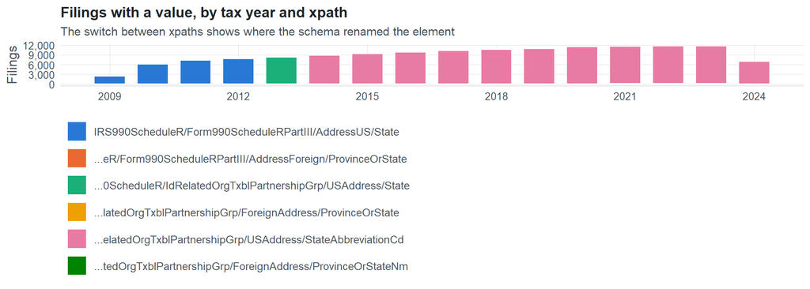

**Table view**

Table view: filings by tax year and series

| Tax year | IRS990ScheduleR/Form990ScheduleRPartIII/AddressUS/State | …eR/Form990ScheduleRPartIII/AddressForeign/ProvinceOrState | …0ScheduleR/IdRelatedOrgTxblPartnershipGrp/USAddress/State | …latedOrgTxblPartnershipGrp/ForeignAddress/ProvinceOrState | …elatedOrgTxblPartnershipGrp/USAddress/StateAbbreviationCd | …tedOrgTxblPartnershipGrp/ForeignAddress/ProvinceOrStateNm |
| --- | --- | --- | --- | --- | --- | --- |
| 2009 | 2,408 | 18 | 0 | 0 | 0 | 0 |
| 2010 | 6,092 | 25 | 0 | 0 | 0 | 0 |
| 2011 | 7,239 | 29 | 0 | 0 | 0 | 0 |
| 2012 | 7,721 | 38 | 0 | 0 | 0 | 0 |
| 2013 | 0 | 0 | 8,258 | 43 | 0 | 0 |
| 2014 | 0 | 0 | 0 | 0 | 8,789 | 42 |
| 2015 | 0 | 0 | 0 | 0 | 9,294 | 77 |
| 2016 | 0 | 0 | 0 | 0 | 9,719 | 77 |
| 2017 | 0 | 0 | 0 | 0 | 10,305 | 69 |
| 2018 | 0 | 0 | 0 | 0 | 10,609 | 74 |
| 2019 | 0 | 0 | 0 | 0 | 10,877 | 87 |
| 2020 | 0 | 0 | 0 | 0 | 11,397 | 91 |
| 2021 | 0 | 0 | 0 | 0 | 11,570 | 103 |
| 2022 | 0 | 0 | 0 | 0 | 11,667 | 123 |
| 2023 | 0 | 0 | 0 | 0 | 11,569 | 132 |
| 2024 | 0 | 0 | 0 | 0 | 6,909 | 45 |

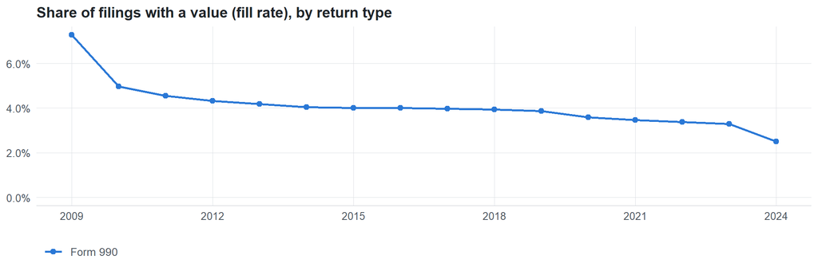

**Table view**

Table view: fill rate

| Tax year | Return type | Filings | All filings | Fill rate |
| --- | --- | --- | --- | --- |
| 2009 | Form 990 | 2,426 | 33,311 | 7.28% |
| 2010 | Form 990 | 6,117 | 123,025 | 4.97% |
| 2011 | Form 990 | 7,268 | 159,504 | 4.56% |
| 2012 | Form 990 | 7,759 | 179,688 | 4.32% |
| 2013 | Form 990 | 8,301 | 198,855 | 4.17% |
| 2014 | Form 990 | 8,831 | 218,619 | 4.04% |
| 2015 | Form 990 | 9,371 | 233,519 | 4.01% |
| 2016 | Form 990 | 9,796 | 243,903 | 4.02% |
| 2017 | Form 990 | 10,374 | 261,612 | 3.97% |
| 2018 | Form 990 | 10,683 | 271,442 | 3.94% |
| 2019 | Form 990 | 10,964 | 283,694 | 3.86% |
| 2020 | Form 990 | 11,488 | 320,342 | 3.59% |
| 2021 | Form 990 | 11,673 | 336,480 | 3.47% |
| 2022 | Form 990 | 11,790 | 349,055 | 3.38% |
| 2023 | Form 990 | 11,701 | 354,768 | 3.30% |
| 2024 | Form 990 | 6,954 | 277,298 | 2.51% |

## Repeating groups

Table cardinality in the concordance: **many**. 6 of 6 observed xpaths repeat within a filing.

Repeating element each xpath was observed in (from the raw indexed xpath)

| Xpath | Repeating element | Filings (summed over years) |
| --- | --- | --- |
| IRS990ScheduleR/Form990ScheduleRPartIII/AddressForeign/ProvinceOrState | (none) | 12 |
| IRS990ScheduleR/Form990ScheduleRPartIII/AddressForeign/ProvinceOrState | IRS990ScheduleR/Form990ScheduleRPartIII | 98 |
| IRS990ScheduleR/Form990ScheduleRPartIII/AddressUS/State | (none) | 8148 |
| IRS990ScheduleR/Form990ScheduleRPartIII/AddressUS/State | IRS990ScheduleR/Form990ScheduleRPartIII | 15312 |
| IRS990ScheduleR/IdRelatedOrgTxblPartnershipGrp/ForeignAddress/ProvinceOrState | (none) | 11 |
| IRS990ScheduleR/IdRelatedOrgTxblPartnershipGrp/ForeignAddress/ProvinceOrState | IRS990ScheduleR/IdRelatedOrgTxblPartnershipGrp | 32 |
| IRS990ScheduleR/IdRelatedOrgTxblPartnershipGrp/USAddress/State | (none) | 2857 |
| IRS990ScheduleR/IdRelatedOrgTxblPartnershipGrp/USAddress/State | IRS990ScheduleR/IdRelatedOrgTxblPartnershipGrp | 5401 |
| IRS990ScheduleR/IdRelatedOrgTxblPartnershipGrp/ForeignAddress/ProvinceOrStateNm | (none) | 127 |
| IRS990ScheduleR/IdRelatedOrgTxblPartnershipGrp/ForeignAddress/ProvinceOrStateNm | IRS990ScheduleR/IdRelatedOrgTxblPartnershipGrp | 793 |
| IRS990ScheduleR/IdRelatedOrgTxblPartnershipGrp/USAddress/StateAbbreviationCd | (none) | 37222 |
| IRS990ScheduleR/IdRelatedOrgTxblPartnershipGrp/USAddress/StateAbbreviationCd | IRS990ScheduleR/IdRelatedOrgTxblPartnershipGrp | 75483 |

## Values

| Result | Check | Detail |
| --- | --- | --- |
| ✓ pass | Small code list | up to 59 distinct values per xpath and year |
| ✓ pass | Codes share one format | 99% have the shape AA |
| ✓ pass | Consistent letter case | 0.0% of values are lower case |

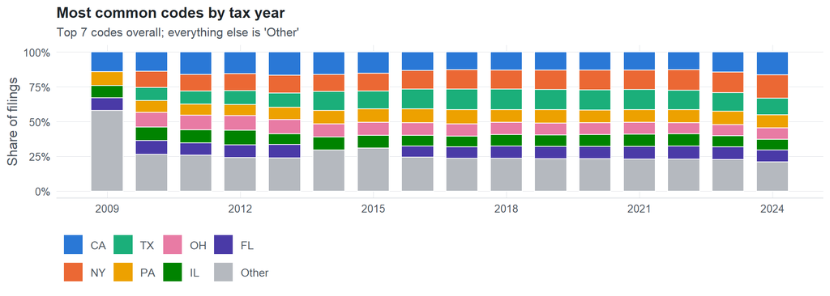

**Table view**

Table view: filings by code and tax year

| tax_year | CA | NY | TX | PA | OH | IL | FL | Other |
| --- | --- | --- | --- | --- | --- | --- | --- | --- |
| 2009 | 316 | 0 | 0 | 220 | 0 | 196 | 199 | 1,292 |
| 2010 | 944 | 771 | 641 | 573 | 720 | 654 | 661 | 1,789 |
| 2011 | 1,265 | 940 | 717 | 623 | 829 | 731 | 702 | 2,011 |
| 2012 | 1,376 | 1,076 | 885 | 696 | 918 | 934 | 811 | 2,116 |
| 2013 | 1,497 | 1,145 | 921 | 784 | 938 | 691 | 846 | 2,149 |
| 2014 | 1,615 | 1,210 | 1,384 | 964 | 949 | 926 | 0 | 2,954 |
| 2015 | 1,638 | 1,355 | 1,386 | 1,036 | 995 | 982 | 0 | 3,313 |
| 2016 | 1,496 | 1,495 | 1,617 | 1,095 | 1,031 | 860 | 909 | 2,743 |
| 2017 | 1,539 | 1,638 | 1,785 | 1,231 | 1,072 | 889 | 1,012 | 2,813 |
| 2018 | 1,825 | 1,961 | 2,093 | 1,277 | 1,232 | 1,170 | 1,255 | 3,332 |
| 2019 | 1,882 | 1,983 | 2,092 | 1,361 | 1,224 | 1,215 | 1,252 | 3,337 |
| 2020 | 1,929 | 2,056 | 2,161 | 1,336 | 1,245 | 1,241 | 1,320 | 3,408 |
| 2021 | 1,941 | 2,105 | 2,151 | 1,388 | 1,249 | 1,328 | 1,374 | 3,431 |
| 2022 | 1,968 | 2,276 | 2,104 | 1,461 | 1,234 | 1,330 | 1,431 | 3,546 |
| 2023 | 2,240 | 2,279 | 2,097 | 1,521 | 1,201 | 1,262 | 1,404 | 3,525 |
| 2024 | 1,278 | 1,285 | 938 | 718 | 645 | 586 | 659 | 1,633 |

Code frequencies (all xpaths, all years)

| Code | Filings | Share |
| --- | --- | --- |
| CA | 24,749 | 14.1% |
| NY | 23,575 | 13.4% |
| TX | 22,972 | 13.1% |
| PA | 16,284 | 9.3% |
| OH | 15,482 | 8.8% |
| IL | 14,995 | 8.6% |
| FL | 13,835 | 7.9% |
| MI | 12,000 | 6.8% |
| MA | 9,877 | 5.6% |
| WA | 9,361 | 5.3% |
| KS | 4,178 | 2.4% |
| MD | 2,350 | 1.3% |
| CO | 1,458 | 0.8% |
| NJ | 1,196 | 0.7% |
| TN | 1,048 | 0.6% |
| GRAND CAYMAN | 317 | 0.2% |
| ID | 200 | 0.1% |
| AL | 194 | 0.1% |
| IA | 193 | 0.1% |
| GR | 134 | 0.1% |
| Grand Cayman | 106 | 0.1% |
| ALBERTA | 76 | 0.0% |
| CHANNEL ISLANDS | 66 | 0.0% |
| ON | 60 | 0.0% |
| ONTARIO | 57 | 0.0% |
| MAHARASHTRA | 57 | 0.0% |
| MUMBAI | 55 | 0.0% |
| SANTIAGO | 40 | 0.0% |
| GERMANY | 35 | 0.0% |
| BD | 28 | 0.0% |

First rows shown.

## Examples

| Tax year | Return | Xpath | Organization | Value | Source |
| --- | --- | --- | --- | --- | --- |
| 2024 | 990 | IRS990ScheduleR/IdRelatedOrgTxblPartnershipGrp/ForeignAddress/ProvinceOrStateNm | THE CLEVELAND CLINIC FOUNDATION | GRAND CAYMAN | [XML](https://gt990datalake-rawdata.s3.amazonaws.com/EfileData/XmlFiles/202513189349302136_public.xml) |
| 2024 | 990 | IRS990ScheduleR/IdRelatedOrgTxblPartnershipGrp/USAddress/StateAbbreviationCd | THE CLEVELAND CLINIC FOUNDATION | OH | [XML](https://gt990datalake-rawdata.s3.amazonaws.com/EfileData/XmlFiles/202513189349302136_public.xml) |
| 2023 | 990 | IRS990ScheduleR/IdRelatedOrgTxblPartnershipGrp/ForeignAddress/ProvinceOrStateNm | THE FULLER FOUNDATION | GRAND CAYMAN | [XML](https://gt990datalake-rawdata.s3.amazonaws.com/EfileData/XmlFiles/202403169349306145_public.xml) |
| 2023 | 990 | IRS990ScheduleR/IdRelatedOrgTxblPartnershipGrp/USAddress/StateAbbreviationCd | Neurology Associates of Stony Brook University Faculty Practice Corp | NY | [XML](https://gt990datalake-rawdata.s3.amazonaws.com/EfileData/XmlFiles/202531339349306648_public.xml) |
| 2022 | 990 | IRS990ScheduleR/IdRelatedOrgTxblPartnershipGrp/ForeignAddress/ProvinceOrStateNm | SKECHERS FOUNDATION | ST HELIER | [XML](https://gt990datalake-rawdata.s3.amazonaws.com/EfileData/XmlFiles/202333199349320973_public.xml) |
| 2022 | 990 | IRS990ScheduleR/IdRelatedOrgTxblPartnershipGrp/USAddress/StateAbbreviationCd | Providence Brown Street Housing | NY | [XML](https://gt990datalake-rawdata.s3.amazonaws.com/EfileData/XmlFiles/202411239349300546_public.xml) |
| 2021 | 990 | IRS990ScheduleR/IdRelatedOrgTxblPartnershipGrp/ForeignAddress/ProvinceOrStateNm | Second Century Foundation | LAKE COUNTRY | [XML](https://gt990datalake-rawdata.s3.amazonaws.com/EfileData/XmlFiles/202223189349303632_public.xml) |
| 2021 | 990 | IRS990ScheduleR/IdRelatedOrgTxblPartnershipGrp/USAddress/StateAbbreviationCd | St John Providence | MO | [XML](https://gt990datalake-rawdata.s3.amazonaws.com/EfileData/XmlFiles/202311329349304191_public.xml) |
| 2020 | 990 | IRS990ScheduleR/IdRelatedOrgTxblPartnershipGrp/ForeignAddress/ProvinceOrStateNm | ISLES INC | HAMILTON HM 11 | [XML](https://gt990datalake-rawdata.s3.amazonaws.com/EfileData/XmlFiles/202143159349303084_public.xml) |
| 2020 | 990 | IRS990ScheduleR/IdRelatedOrgTxblPartnershipGrp/USAddress/StateAbbreviationCd | SMYRNA RHF HOUSING INC | MA | [XML](https://gt990datalake-rawdata.s3.amazonaws.com/EfileData/XmlFiles/202240179349300204_public.xml) |
| 2019 | 990 | IRS990ScheduleR/IdRelatedOrgTxblPartnershipGrp/ForeignAddress/ProvinceOrStateNm | CLINICAL CARE ASSOCIATES OF THE | GRAND CAYMAN | [XML](https://gt990datalake-rawdata.s3.amazonaws.com/EfileData/XmlFiles/202101339349302155_public.xml) |
| 2019 | 990 | IRS990ScheduleR/IdRelatedOrgTxblPartnershipGrp/USAddress/StateAbbreviationCd | SOUTHFIELD NON-PROFIT HOUSING CORP | MI | [XML](https://gt990datalake-rawdata.s3.amazonaws.com/EfileData/XmlFiles/202013169349303486_public.xml) |

## Reviewer checklist

- The definition matches the form line and instructions for every xpath’s schema years.
- Every xpath pooled here measures the same thing on the 990 and 990-EZ (close enough for analysis).
- The coverage chart has no unexplained gaps or jumps between tax years.
- Each open flag is fixed, or accepted with a note in validation_log.csv.
- Every code is valid for the list the form uses (state, country, valuation method, …).
- The code list and its meaning did not change across schema versions.
- Codes are stored as text, so values like leading zeros are preserved.

Record the review as a row in `inst/extdata/src/validation_log.csv` (variable_name, reviewer, date, status, note). Evidence built 2026-09-23 17:09:04 MST from the ef2 DuckDB builds (tax years 2009–2024).